# HW 4

Author

Kiran Nagar

```r
library(tidyverse)
```

## Question 1

```r
nfl_data <- read_csv("https://raw.githubusercontent.com/NicolasRestrep/223_course/main/Data/nfl_salaries.csv")
```

Dataset was read in from the link as instructed.

## Question 2

```r
tidy_nfl_data_pivot <- nfl_data %>%
  pivot_longer(cols = "Cornerback":"Wide Receiver",
               names_to = "position",
               values_to = "salary in $M")
tidy_nfl_data_pivot <- tidy_nfl_data_pivot %>%
  mutate(`salary in $M` = (`salary in $M`/(10^6)))
tidy_nfl_data_pivot
```

```
# A tibble: 8,000 × 3
    year position          `salary in $M`
   <dbl> <chr>                      <dbl>
 1  2011 Cornerback                 11.3
 2  2011 Defensive Lineman          17.8
 3  2011 Linebacker                 16.4
 4  2011 Offensive Lineman          16.0
 5  2011 Quarterback                17.2
 6  2011 Running Back               13.0
 7  2011 Safety                      8.87
 8  2011 Special Teamer              4.3
 9  2011 Tight End                   8.73
10  2011 Wide Receiver              16.2
# ℹ 7,990 more rows
```

Dataset was reshaped so that every row tells us the salary associated with a position in a certain year.

## Question 3

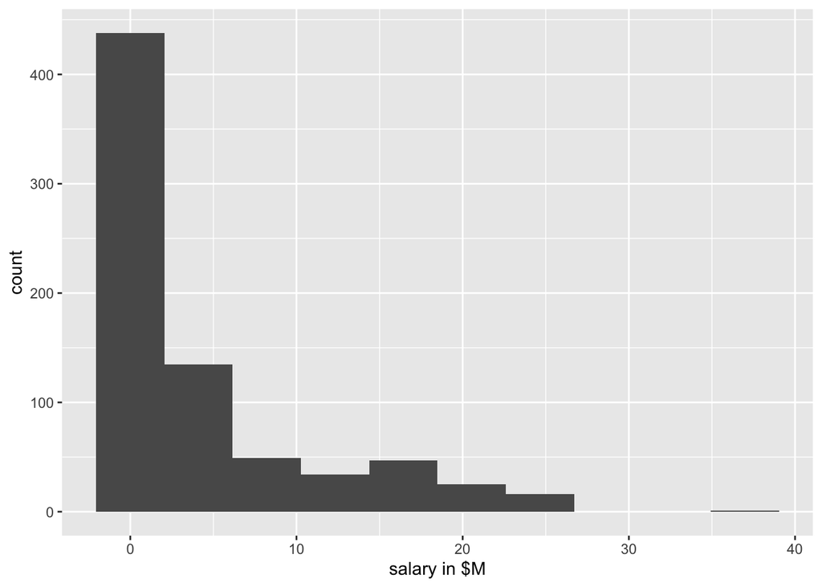

```r
qbs_only <- tidy_nfl_data_pivot %>% filter(position == 'Quarterback')

ggplot(qbs_only, aes(x = `salary in $M`)) + geom_histogram(bins = 10)
```

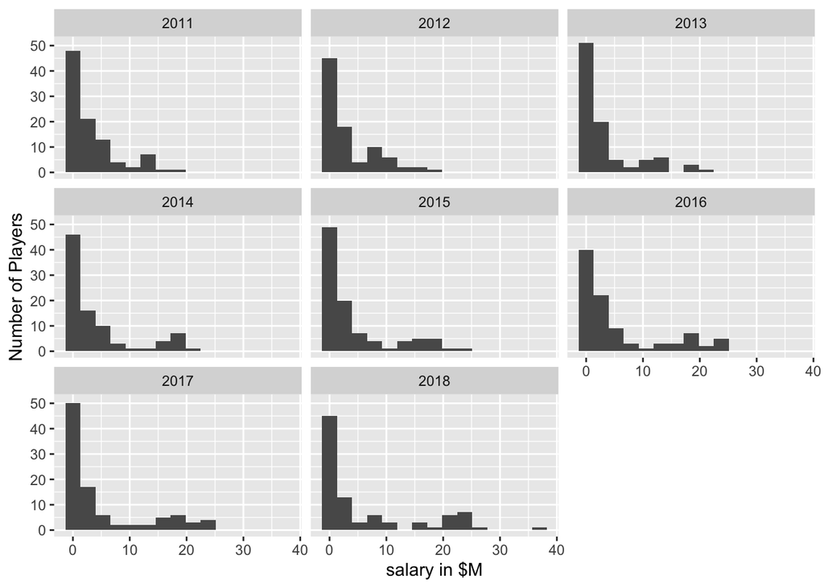

```r
ggplot(qbs_only, aes(x = `salary in $M`)) + geom_histogram(bins = 15) + facet_wrap(vars(year)) + labs(y = "Number of Players")
```

I notice that there are a lot of quarterbacks who earn on the low end of the distribution every year, and then a few outliers earning at a high level. This makes sense to me, because every team has two backup quarterbacks earning a small salary, and one main option earning at a high level.